# Data Mining: Titanic, Survived vs others.

```r
library("caret");
library("ggplot2");
library("magrittr");
library("plot3D");
library("dplyr");
# Multiple plot function
#
# ggplot objects can be passed in ..., or to plotlist (as a list of ggplot objects)
# - cols:   Number of columns in layout
# - layout: A matrix specifying the layout. If present, 'cols' is ignored.
#
# If the layout is something like matrix(c(1,2,3,3), nrow=2, byrow=TRUE),
# then plot 1 will go in the upper left, 2 will go in the upper right, and
# 3 will go all the way across the bottom.
#
multiplot <- function(..., plotlist=NULL, file, cols=1, layout=NULL) {
  library(grid)
  # Make a list from the ... arguments and plotlist
  plots <- c(list(...), plotlist)
  numPlots = length(plots)
  # If layout is NULL, then use 'cols' to determine layout
  if (is.null(layout)) {
    # Make the panel
    # ncol: Number of columns of plots
    # nrow: Number of rows needed, calculated from # of cols
    layout <- matrix(seq(1, cols * ceiling(numPlots/cols)),
                    ncol = cols, nrow = ceiling(numPlots/cols))
  }
 if (numPlots==1) {
    print(plots[[1]])
  } else {
    # Set up the page
    grid.newpage()
    pushViewport(viewport(layout = grid.layout(nrow(layout), ncol(layout))))
    # Make each plot, in the correct location
    for (i in 1:numPlots) {
      # Get the i,j matrix positions of the regions that contain this subplot
      matchidx <- as.data.frame(which(layout == i, arr.ind = TRUE))
      print(plots[[i]], vp = viewport(layout.pos.row = matchidx$row,
                                      layout.pos.col = matchidx$col))
    }
  }
}
```

```r
set.seed(1);
df          <- read.csv("train.csv");
df$Survived <- as.factor(df$Survived);
intrain <- createDataPartition(
  y = df$Survived,  ##  0 is dead, 1 is survived.
  p = 0.75,
  list = FALSE
);
train <- df[intrain,];
str(train)
```

```
'data.frame':   669 obs. of  12 variables:
 $ PassengerId: int  2 3 4 5 9 11 12 13 15 16 ...
 $ Survived   : Factor w/ 2 levels "0","1": 2 2 2 1 2 2 2 1 1 2 ...
 $ Pclass     : int  1 3 1 3 3 3 1 3 3 2 ...
 $ Name       : Factor w/ 891 levels "Abbing, Mr. Anthony",..: 191 358 277 16 417 732 96 734 847 364 ...
 $ Sex        : Factor w/ 2 levels "female","male": 1 1 1 2 1 1 1 2 1 1 ...
 $ Age        : num  38 26 35 35 27 4 58 20 14 55 ...
 $ SibSp      : int  1 0 1 0 0 1 0 0 0 0 ...
 $ Parch      : int  0 0 0 0 2 1 0 0 0 0 ...
 $ Ticket     : Factor w/ 681 levels "110152","110413",..: 597 670 50 473 345 617 39 536 414 154 ...
 $ Fare       : num  71.28 7.92 53.1 8.05 11.13 ...
 $ Cabin      : Factor w/ 148 levels "","A10","A14",..: 83 1 57 1 1 147 51 1 1 1 ...
 $ Embarked   : Factor w/ 4 levels "","C","Q","S": 2 4 4 4 4 4 4 4 4 4 ...
```

In Titanic data, is classification problem, Y is “Survived”, 0 means dead, 1 means life, dimension of variable X is 11.

### In “Pclass” and “Survived”

1. Rate of dead is higher if Ticket class of people is 3.
2. Rate of dead is half if Ticket class of people is 2.
3. Rate of survived is higher if Ticket class of people is 1.

I guess Ticket class 1 is VIP.

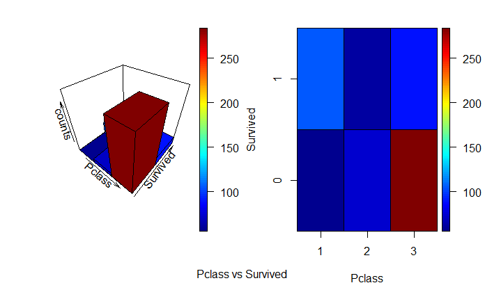

```
      Survived
Pclass         0         1
     1 0.3478261 0.6521739
     2 0.5373134 0.4626866
     3 0.7593583 0.2406417
```

### In “Sex” and “Survived”

1. Rate of dead is higher if male.
2. Rate of survived is higher if female.

Gentlemen.

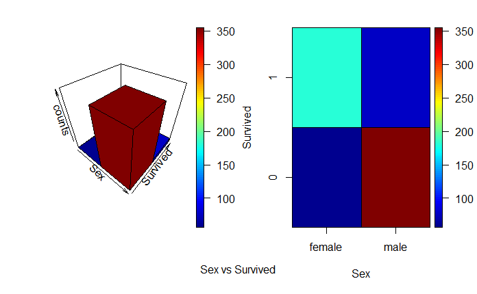

```
        Survived
Sex              0         1
  female 0.2405063 0.7594937
  male   0.8217593 0.1782407
```

### In “Age” and “Survived”

1. There are missing data in “Age”.
2. I found the rate of dead is lower if age less than 10 only.

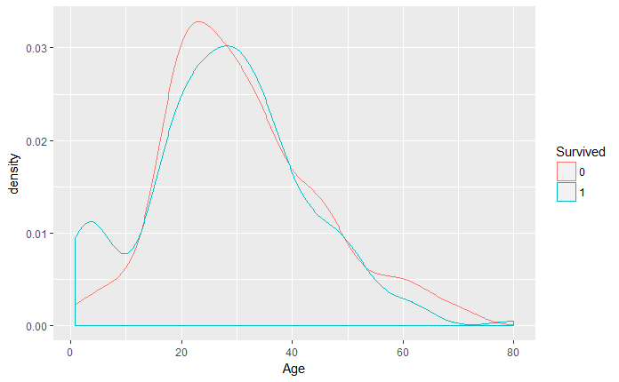

### In “SibSp” and “Survived”

“SibSp” means brothers and sisters.  
1. 465 people not have brothers and sisters.  
2. 6 people have 8 “SibSp”.

```
SibSp
  0   1   2   3   4   5   8
465 152  21  10  10   5   6
```

```
    0   1     0     1
0 301 164 0.647 0.353
1  72  80 0.474 0.526
2  13   8 0.619 0.381
3   6   4 0.600 0.400
4   9   1 0.900 0.100
5   5   0 1.000 0.000
8   6   0 1.000 0.000
```

### In “Parch” and “Survived”

“Parch” means parents and children.  
1. There are 523 people that have no parents and children.

```
Parch
  0   1   2   3   4   5   6
523  76  61   1   3   4   1
```

2. Rate of dead < 50%, if have 1 or 2, parents and children.

```
    0   1     0     1
0 342 181 0.654 0.346
1  35  41 0.461 0.539
2  28  33 0.459 0.541
3   0   1 0.000 1.000
4   3   0 1.000 0.000
5   3   1 0.750 0.250
6   1   0 1.000 0.000
```

### In “Fare” and “Survived”

“Fare” means passenger fare, no missing data.

1. “Fare” is numeric and have 223 types.

```
   Min. 1st Qu.  Median    Mean 3rd Qu.    Max.
  0.000   7.896  14.400  31.927  31.275 512.329
```

2. High rate of people dead if “Fare” is some vlaues.
3. If “Fare” higher, then you probably survive.

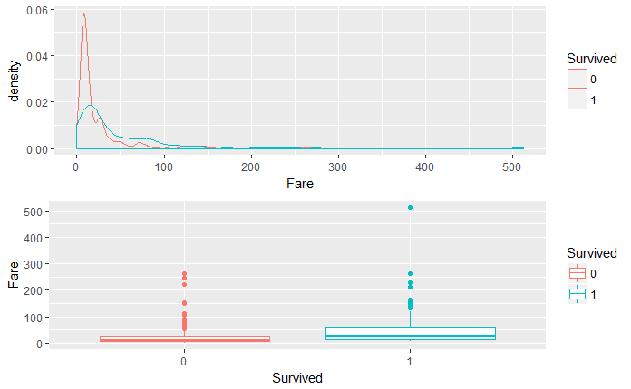

### In “Embarked” and “Survived”

Embarked" means port of embarkation, there two people I don’t know where they embark.

```
Embarked
      C   Q   S
  2 126  55 486
```

```
    0   1      0      1
    0   2 0.0000 1.0000
C  57  69 0.4524 0.5476
Q  34  21 0.6182 0.3818
S 321 165 0.6605 0.3395
```